# DDP Project: Shiny Apps for Data Exploration

cyanophyta

02/09/2017

# Goal of the application

- While exploring a dataset we need to study basic plots of various variables of a dataset.
- We attempt to make this work easier by using a Shiny Apps application here.
- Dataset considered here is faithfuld from ggplot2 package.

```r
library(ggplot2, warn.conflicts = FALSE, quietly = TRUE)
data("faithfuld")
dim(faithfuld)
```

```
## [1] 5625    3
```

```r
str(faithfuld)
```

```
## Classes 'tbl_df', 'tbl' and 'data.frame':    5625 obs. of  3 variables:
##  $ eruptions: num  1.6 1.65 1.69 1.74 1.79 ...
##  $ waiting  : num  43 43 43 43 43 43 43 43 43 43 ...
##  $ density  : num  0.00322 0.00384 0.00444 0.00498 0.00542 ...
```

# App features

Using this app, user can

- study Histogram, Line Graph or Box-and-whisker Plot of any variable in the dataset
- change color of the graph, if needed
- in case of histogram, change number of intervals (bins) to be used in the graph
- study summary data for the selected variable, displayed in the following format:

```r
  summat <- as.matrix(summary(faithfuld$waiting))
  rownames(summat) <- c("Minimum", "1st quartile", "Median", "Mean", "3rd quartile", "Maximum")
  colnames(summat) <- "Summary"
  summat
```

```
##               Summary
## Minimum      43.00000
## 1st quartile 55.89189
## Median       69.50000
## Mean         69.50000
## 3rd quartile 83.10811
## Maximum      96.00000
```

# Sample plot types for variable ‘waiting’

User selects one of the variables of the dataset in the Shiny app. Based on this selection, and type of graph/color, one of the available graph is displayed by the app.

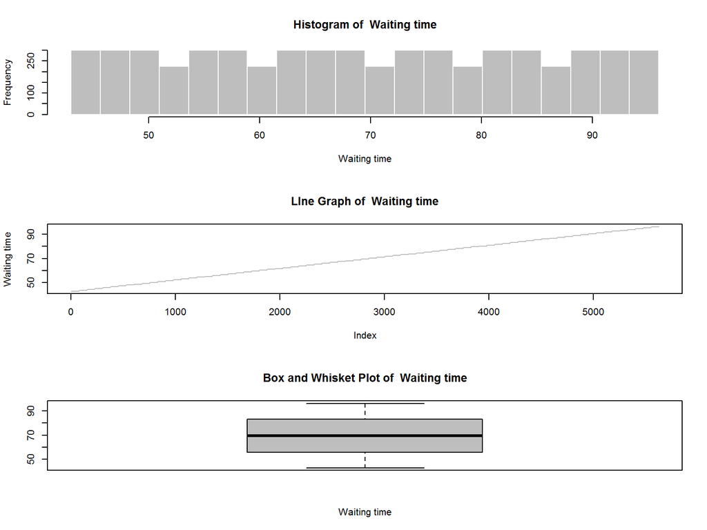

# Possible future enhancements

- add more tuning parameters for the graphs
- add a tab to select any of the two variables and show scatter plot
- add a tab, where user can select multiple variables and then display pairwise scatter plots